# PredictionAssignment

Mary Saldanha

September 17, 2017

### Prediction Assignment : Human Activity Recognition

This assignment is to predict the manner of the exercise performed by 6 participants, using the Weight Lifting Exercises (WLE) Dataset.

The data for this assignment is from the source: http://web.archive.org/web/20161224072740/http:/groupware.les.inf.puc-rio.br/har.

There are two dataset files - Training and Testing and the outcome is in classe. The classe values are A - Exercise is performed exactly according to specification B - Throwing the elbows to tehe front C - Lifting the dumbbell halfway D - Lowering dumbbell halfway E - Throwing the hips to the front

```r
dim(training)
```

```
## [1] 19622   160
```

## Data cleansing

The 160 variables is a lot of dimensions to look at, hence to clean up data and remove redundant variables.

- Remove statistical variables
- Remove date and times, user info which are not related to the final outcome
- Roll, pitch and yaw are derived from gyros, magnet and accel, hence one or the other can be used, for the analysis below, roll, pitch and yaw has been used

## Cross Validation

To perform cross validation, as we have a training set, the training set will be split further into a training train_1, and testing data set test_1.

We create a linermodel on the train_1 dataset and check the coefficients to see if we have all the necessary variables.

Summary of linear model coefficients

```
##
## Call:
## lm(formula = class ~ . - classe, data = train_2)
##
## Residuals:
##     Min      1Q  Median      3Q     Max
## -3.4196 -1.0522 -0.0121  0.9144  4.6695
##
## Coefficients:
##                  Estimate Std. Error t value Pr(>|t|)
## (Intercept)     1.7791166  0.0573034  31.047  < 2e-16 ***
## roll_belt       0.0091377  0.0007255  12.596  < 2e-16 ***
## pitch_belt     -0.0152802  0.0016864  -9.061  < 2e-16 ***
## yaw_belt       -0.0068007  0.0006226 -10.924  < 2e-16 ***
## roll_arm        0.0018703  0.0002326   8.041 9.83e-16 ***
## pitch_arm      -0.0079119  0.0004385 -18.042  < 2e-16 ***
## yaw_arm         0.0003043  0.0002008   1.515    0.130
## roll_dumbbell   0.0014937  0.0002324   6.427 1.35e-10 ***
## pitch_dumbbell -0.0005545  0.0004785  -1.159    0.246
## yaw_dumbbell   -0.0026064  0.0002607  -9.996  < 2e-16 ***
## roll_forearm    0.0007458  0.0001289   5.784 7.50e-09 ***
## pitch_forearm   0.0181327  0.0005293  34.256  < 2e-16 ***
## yaw_forearm     0.0001669  0.0001441   1.158    0.247
## ---
## Signif. codes:  0 '***' 0.001 '**' 0.01 '*' 0.05 '.' 0.1 ' ' 1
##
## Residual standard error: 1.339 on 10782 degrees of freedom
## Multiple R-squared:  0.1776, Adjusted R-squared:  0.1766
## F-statistic:   194 on 12 and 10782 DF,  p-value: < 2.2e-16
```

```
##                  Overall
## roll_belt      12.595659
## pitch_belt      9.061059
## yaw_belt       10.923571
## roll_arm        8.041175
## pitch_arm      18.042342
## yaw_arm         1.515228
## roll_dumbbell   6.427301
## pitch_dumbbell  1.158991
## yaw_dumbbell    9.995755
## roll_forearm    5.783937
## pitch_forearm  34.255834
## yaw_forearm     1.157834
```

Models applied are : rainforest and gbm (Gradient boosting machine) on the training dataset.

The prediction is applied on the test_1 dataset.

We then stack the predictions from the above and perform training and prediction on the test_2 dataset. We then check the Accuracy as shown in Appendix.

The trained models are then applied to the testing/validation data set. The predicted values are as follows :

```r
predfit <- predict(trainfit,test_df)
predfit
```

```
##  [1] B A B A A E D B A A B C B A E E A B B B
## Levels: A B C D E
```

Estimated error using the respective models and the combined model, against test_1 dataset is as below. Refer Accuracy in Appendix for detailed information.

```
## [1] 12.08305
```

```
## [1] 25.29822
```

```
## [1] 12.04159
```

# Residual plot

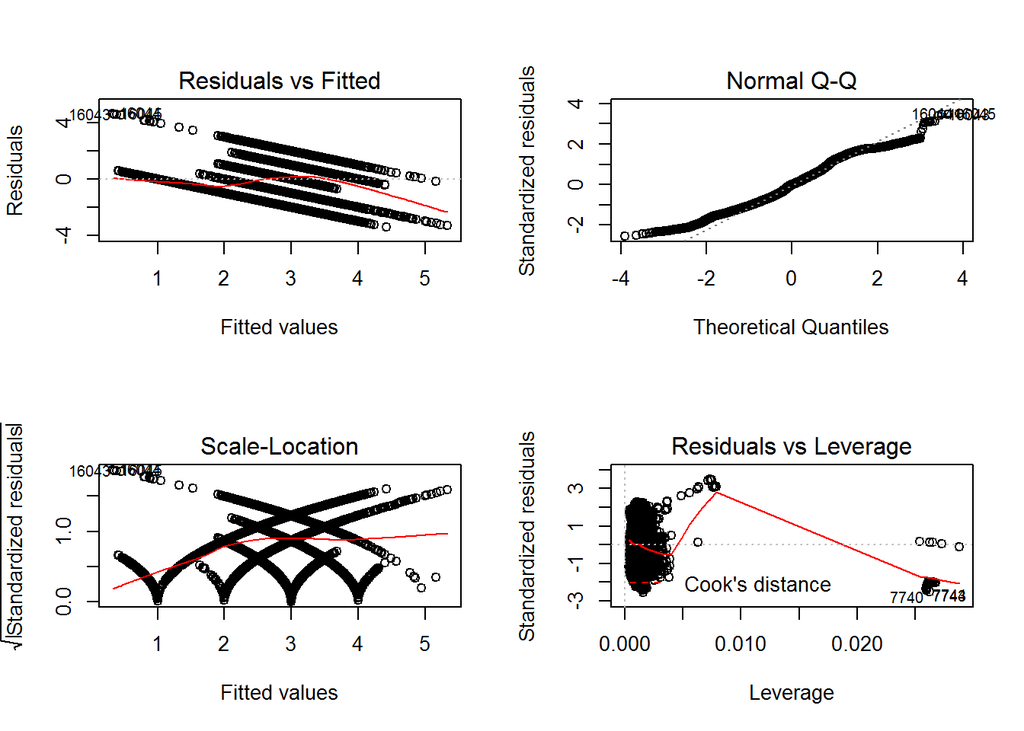

```r
par(mfrow=c(2,2))
plot(mdl)
```

# List of predictors

```r
finalcols
```

```
##  [1] "roll_belt"      "pitch_belt"     "yaw_belt"       "roll_arm"
##  [5] "pitch_arm"      "yaw_arm"        "roll_dumbbell"  "pitch_dumbbell"
##  [9] "yaw_dumbbell"   "roll_forearm"   "pitch_forearm"  "yaw_forearm"
## [13] "classe"
```

# Accuracy

```r
confusionMatrix(pred_tr1,test_1$classe)
```

```
## Confusion Matrix and Statistics
##
##           Reference
## Prediction    A    B    C    D    E
##          A 2499   23    0    1    0
##          B    4 1639   13    1    6
##          C    2   38 1509   10   13
##          D    2    6   17 1430    0
##          E    3    2    0    5 1604
##
## Overall Statistics
##
##                Accuracy : 0.9835
##                  95% CI : (0.9806, 0.986)
##     No Information Rate : 0.2844
##     P-Value [Acc > NIR] : < 2.2e-16
##
##                   Kappa : 0.9791
##  Mcnemar's Test P-Value : 1.769e-08
##
## Statistics by Class:
##
##                      Class: A Class: B Class: C Class: D Class: E
## Sensitivity            0.9956   0.9596   0.9805   0.9883   0.9883
## Specificity            0.9962   0.9966   0.9914   0.9966   0.9986
## Pos Pred Value         0.9905   0.9856   0.9599   0.9828   0.9938
## Neg Pred Value         0.9983   0.9904   0.9959   0.9977   0.9974
## Prevalence             0.2844   0.1935   0.1744   0.1639   0.1839
## Detection Rate         0.2831   0.1857   0.1710   0.1620   0.1817
## Detection Prevalence   0.2858   0.1884   0.1781   0.1648   0.1828
## Balanced Accuracy      0.9959   0.9781   0.9859   0.9924   0.9935
```

```r
confusionMatrix(pred_tr2,test_1$classe)
```

```
## Confusion Matrix and Statistics
##
##           Reference
## Prediction    A    B    C    D    E
##          A 2391   67    4    5    2
##          B   61 1515  107   14   33
##          C   17   90 1386   42   35
##          D   22   29   42 1376   34
##          E   19    7    0   10 1519
##
## Overall Statistics
##
##                Accuracy : 0.9275
##                  95% CI : (0.9219, 0.9328)
##     No Information Rate : 0.2844
##     P-Value [Acc > NIR] : < 2.2e-16
##
##                   Kappa : 0.9084
##  Mcnemar's Test P-Value : < 2.2e-16
##
## Statistics by Class:
##
##                      Class: A Class: B Class: C Class: D Class: E
## Sensitivity            0.9526   0.8870   0.9006   0.9509   0.9359
## Specificity            0.9877   0.9698   0.9748   0.9828   0.9950
## Pos Pred Value         0.9684   0.8757   0.8828   0.9155   0.9768
## Neg Pred Value         0.9813   0.9728   0.9789   0.9903   0.9857
## Prevalence             0.2844   0.1935   0.1744   0.1639   0.1839
## Detection Rate         0.2709   0.1716   0.1570   0.1559   0.1721
## Detection Prevalence   0.2797   0.1960   0.1779   0.1703   0.1762
## Balanced Accuracy      0.9701   0.9284   0.9377   0.9669   0.9655
```

```r
confusionMatrix(trainpredict,test_1$classe)
```

```
## Confusion Matrix and Statistics
##
##           Reference
## Prediction    A    B    C    D    E
##          A 2499   23    0    1    0
##          B    4 1639   13    1    6
##          C    2   38 1509   10   12
##          D    2    6   17 1430    0
##          E    3    2    0    5 1605
##
## Overall Statistics
##
##                Accuracy : 0.9836
##                  95% CI : (0.9807, 0.9861)
##     No Information Rate : 0.2844
##     P-Value [Acc > NIR] : < 2.2e-16
##
##                   Kappa : 0.9792
##  Mcnemar's Test P-Value : 2.723e-08
##
## Statistics by Class:
##
##                      Class: A Class: B Class: C Class: D Class: E
## Sensitivity            0.9956   0.9596   0.9805   0.9883   0.9889
## Specificity            0.9962   0.9966   0.9915   0.9966   0.9986
## Pos Pred Value         0.9905   0.9856   0.9605   0.9828   0.9938
## Neg Pred Value         0.9983   0.9904   0.9959   0.9977   0.9975
## Prevalence             0.2844   0.1935   0.1744   0.1639   0.1839
## Detection Rate         0.2831   0.1857   0.1710   0.1620   0.1818
## Detection Prevalence   0.2858   0.1884   0.1780   0.1648   0.1830
## Balanced Accuracy      0.9959   0.9781   0.9860   0.9924   0.9938
```